# Final Exam Review

POSC 459 — Social Welfare Politics and Policy · Week 15, Wednesday 9 December 2026

*Accessible text version of the Week 15 Wednesday slides — same content in linear order, with no slide-scaling container. Each image carries a text description. The review draws on the whole course, Weeks 1 to 15; the week each idea comes from is named on its slide.*

*Getting ready to write about your own program on Monday*

*Our last class*

## Today: review, practice, then your questions

| **1:03** | What we know about Monday’s exam |
| --- | --- |
| **1:06** | What the final asks you to write |
| **1:09** | Six pictures from the term: name the author and the argument |
| **1:25** | Outline your own program in five lines |
| **1:36** | Write one practice section, then trade with a neighbor |
| **1:52** | **Your questions** |
| **2:05** | Reminders, and the last word |

## Monday’s final exam: what to expect

| **When** | Monday, December 14, 1:00–2:50 p.m., GH 305 |
| --- | --- |
| **Bring** | **A blue book**, and a pen or pencil |
| **Rules** | By hand. Closed book, closed notes. Red: no AI, no devices |
| **Part I** | Four answers on your program, 15 points each |
| **Part II** | What you would change: two questions, answer one. 40 points |

*100 points, 20% of your grade · No program yet? Yours is Social Security*

## The final asks you to write about your own program

Write at length about **your own program**, answering five questions:

1. What does it do?
2. Whom does it reach?
3. How was it built?
4. What is the argument over it?
5. What would you change?

Throughout, use the course’s ideas and evidence: “applying the concepts and evidence of the course throughout”

*Source: the syllabus, “Graded Work”*

## 1. In 1935, who ran which program?

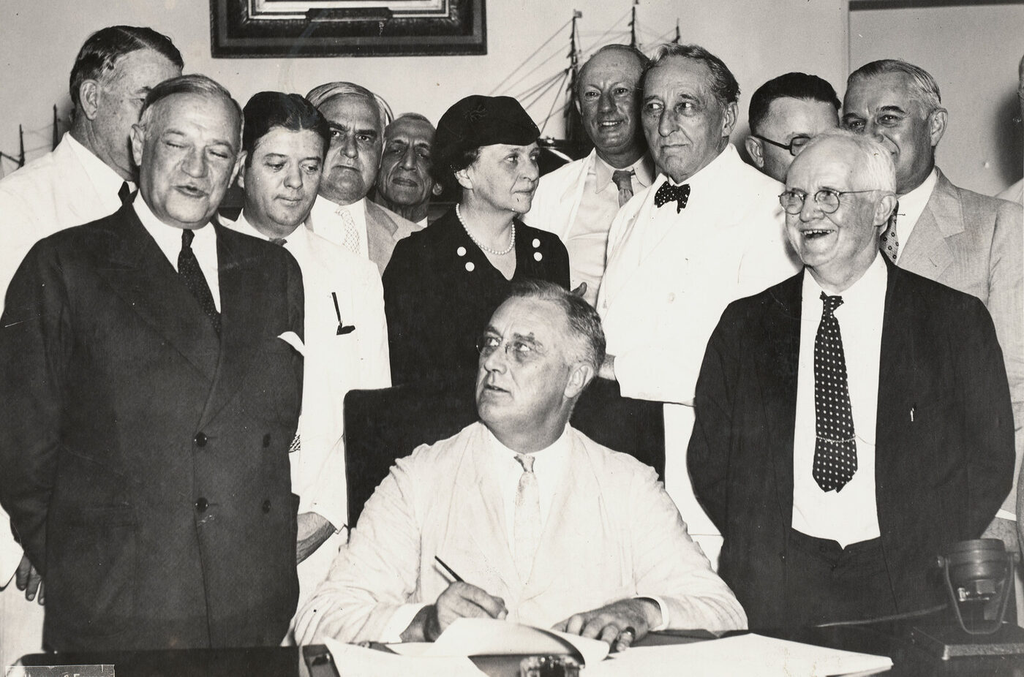

Roosevelt signs the Social Security Act, August 14, 1935

**On your own, 30 seconds. Write down:**

- Which programs did Washington run, and which did it leave to the states?
- Whose argument is this, and which week?

*Photo: FDR Library, CC BY 2.0 · shown in Week 13*

## 2. Why did aid to mothers vary by state?

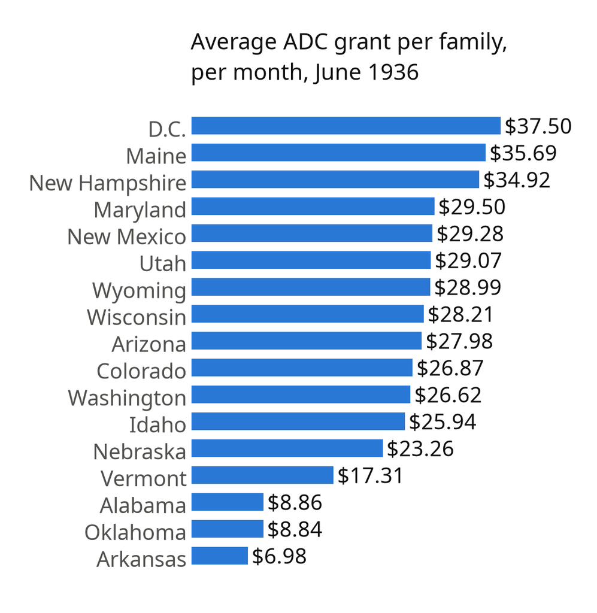

ADC = Aid to Dependent Children. Bars: average monthly grant per family, June 1936, in the 17 states then in the program

**On your own, 30 seconds. Write down:**

- Why did the grant differ so much from state to state?
- What is this program called today?
- Whose argument, and which week?

*Mettler, table 6, p. 160 · shown in Week 13*

## 3. Who did magazines picture as poor?

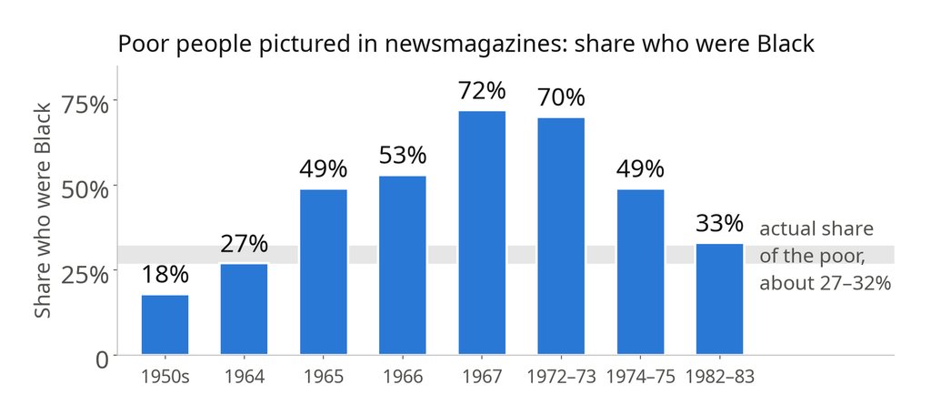

Bars: share of poor people in *Time*, *Newsweek*, and *U.S. News* photos who were Black. Gray band: the real share of poor Americans who were Black

**On your own, 30 seconds. Write down:** whose study this is, which week, and what these pictures did to support for welfare

*Chart: Gilens 1999, pp. 114, 117, 123–24, 126 · shown in Weeks 12, 13*

## 4. Why did cash aid shrink, and stay small?

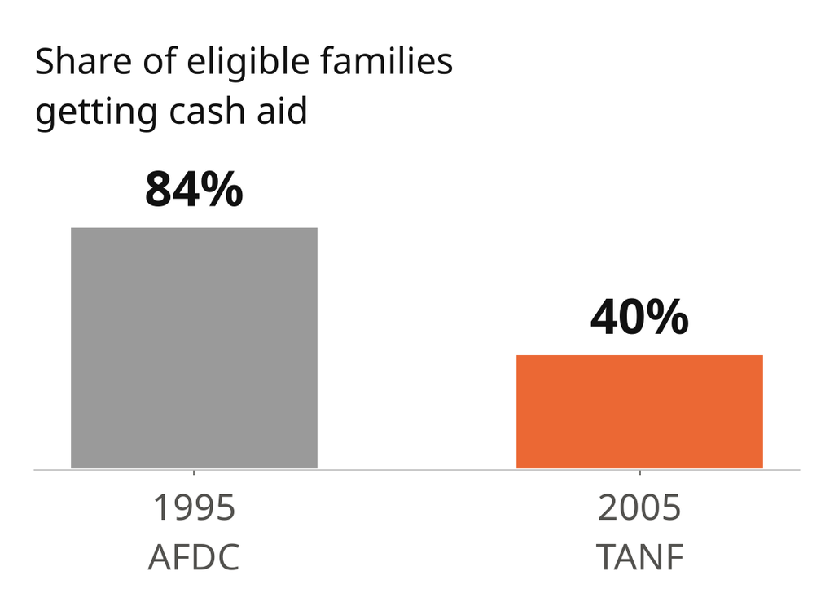

AFDC, then TANF: cash aid for poor families with children

Dec. 2007 to Dec. 2009: unemployment doubled, but families on TANF rose only **13%**

**On your own, 30 seconds. Write down:**

- What law came between 1995 and 2005?
- Who fought to bring the aid back? Whose reading, which week?

*Béland and Waddan, pp. 67–68 · shown in Weeks 9, 11*

## 5. Three questions about one law

[figure not shown]

President Obama signs the Affordable Care Act (ACA), March 23, 2010

**On your own, 30 seconds. Write down:**

- Jacob Hacker asked three questions about this law. What were they?
- Which week?

*Lawrence Jackson, White House, CC BY 2.0 · Week 13*

## 6. Who decides if poor adults get Medicaid?

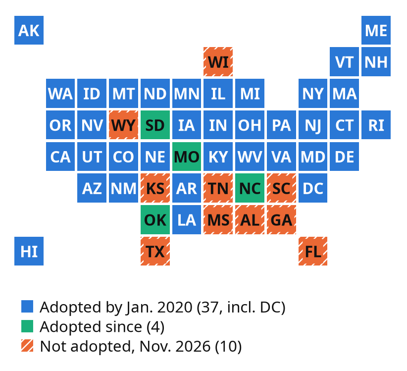

Map: states that have expanded Medicaid to low-income adults under the ACA, as of November 2026

**On your own, 30 seconds. Write down:**

- Who made the expansion optional, and when?
- Who is left out in the states that said no?
- Whose argument, and which week?

*KFF, Nov. 6, 2026 · Michener, p. 552 · shown in Week 13*

## Answers, pictures 1 to 3

|  | The answer | Whose argument |
| --- | --- | --- |
| 1 | Washington ran old-age insurance for wage earners. The states set the rules for unemployment insurance and aid to mothers (ADC) | Mettler, Week 13 |
| 2 | Each state set its own benefit; Washington added $1 for every $2 a state spent. ADC is today’s TANF | Mettler, Week 13; Campbell, Week 9 |
| 3 | Magazines pictured the poor as Black far more often than they were. The more people think recipients are undeserving, the more they want welfare cut | Gilens, Week 12 |

Score yourself: one point for each author you named.

## Answers, pictures 4 to 6

|  | The answer | Whose argument |
| --- | --- | --- |
| 4 | The 1996 welfare law ended AFDC; TANF replaced it. Recipients had no organized defenders, so nobody won the aid back | Béland and Waddan, Week 9 |
| 5 | Why did it pass? Why was it so limited? Why was it so polarized? | Hacker, Week 10 |
| 6 | The Supreme Court, in 2012 (*NFIB v. Sebelius*). Low-income adults in the 10 states that said no, seven in the South | Michener, Week 13 |

Each picture answers one of Monday’s five questions for somebody’s program. Monday, the program is yours.

## 1. What it does: place your program

[output not shown]

**Write line 1 (90 seconds):** your program’s tier, and the rule that decides who gets in

## 2. Whom it reaches: who gets in, and who doesn’t

| Ask this about your program | Where we learned it |
| --- | --- |
| Which group has the highest rate of use? Which group is the largest share of users? Those can differ | Rank, Eppard, and Bullock, Week 1 |
| How many eligible people never sign up? Desmond calls it “welfare avoidance” | Desmond, Week 6 |
| Does what you get depend on your state? | Campbell, Week 9; Michener, Week 13 |
| Do the rules sort people by work history, race, or gender? | Campbell, Week 6; Gilens and Howard, Week 12; Mettler, Week 13 |

**Write line 2 (90 seconds):** who gets it, who is eligible but doesn’t, and who the rules keep out

## 3. How it was built: who made it, and why

| Ask this about your program | Where we learned it |
| --- | --- |
| Who built it, and what did they want it to do, or hold back? Some programs were built to limit older ones (“layering”) | Howard, Weeks 4, 5 |
| Did Washington run it, or the states? Do you get in as a worker, or by need? | Mettler, Week 13 |
| For its biggest reform: why did it pass, and why in that shape? | Béland and Waddan, Week 9; Hacker, Week 10 |
| What has it built since? People who depend on it (“lock-in”), groups that profit from it, and voters who can or can’t see it | Pierson, Weeks 4, 5, 11 |

**Write line 3 (2 minutes):** one year, who built it, and what they meant it to do or hold back

## 4. The argument over it: who fights, and over what

| Ask this about your program | Where we learned it |
| --- | --- |
| Who organizes to defend it? AARP, the seniors’ lobby, wins more on defense than on offense | Pierson, Week 11; Howard, Week 14 |
| Does the public see the people it serves as deserving? | Gilens, Week 12 |
| Is the problem called poverty (what people lack), or dependency (what aid does to people)? | Béland and Waddan, Week 9 |
| Did it grow quietly (a “favorite son”), or take public cuts (a “political orphan”)? | Howard, Week 6 |

**Write line 4 (90 seconds):** the two sides, and the author who best explains where your program stands

## 5. What you would change: one fix, and who will fight it

| Ask this about your change | Where we learned it |
| --- | --- |
| Would it actually help needy families, or only change things? | Howard, ch. 10, Week 15 |
| Does the tool fit the times? When trust in government is low, tax breaks and rules pass more easily than new spending | Howard, ch. 6, Week 14 |
| Who would pay for it, and who profits from things as they are? | Desmond, Week 15 |
| Who loses, who will block it, and who will defend it once it passes? | Your term paper; Pierson |

**Write line 5 (90 seconds):** one change, and the group that will fight it

## Practice: write one section of Monday’s answer

**On your own, on paper, 8 minutes.** Pick one question and answer it for your program:

**A.** How was it built? Who built it, when, and what did they want it to do or hold back?

**B.** What is the argument over it? Who defends it, who attacks it, and why?

**C.** What would you change? Name one change, who loses, and who will block it.

Start with your answer in one sentence. Then use one course idea by name and one specific fact: a year, a number, or a rule.

## Trade with a neighbor and check for four parts

**2 minutes.** Read your neighbor’s section. Beside each part, write ✓ or “missing”:

| Part | Ask |
| --- | --- |
| **Claim** | Does the first sentence answer the question? |
| **Concept** | Is a course idea named, and used on the program? |
| **Evidence** | Is there a year, a number, a name, or a rule? |
| **So what** | Does it say what that evidence shows? |

Then hand it back. Two volunteers read their first two sentences aloud.

*The four parts come from Week 8’s midterm review*

## Your questions: any week, any reading, your program

| Part of the course | Weeks | The big question | Readings |
| --- | --- | --- | --- |
| I. The big picture | 1–4 | Who is poor? Is the U.S. welfare state small? | Rank; Desmond; Howard; Pierson |
| II. The programs | 5–7 | How does each program work, and for whom? | Howard; Berkowitz and DeWitt; Oberlander; Campbell; Desmond; *Who Cares*; Grogan and Andrews |
| III. Two big reforms | 9–11 | Why did welfare reform (1996) and the ACA (2010) pass, and what happened next? | Béland and Waddan; Campbell; Rank; Jacobs and Skocpol; Hacker; the films |
| IV. The politics | 12–15 | How do race, gender, opinion, and interest groups shape it, and what would fix it? | Gilens; Howard; Michener; Mettler; Desmond; *Who Cares*; Campbell |

## Before Monday: three reminders

**Tonight by 11:59 p.m.:** Reading Journal Checkpoint 2. Five more entries, ten in all

**Missed Monday’s research survey?** You can still take it through Saturday, 12/12:

*uci.questionpro.com/t/Acs2vZ9boh*

**Monday, 12/14, 1:00, GH 305:** the final. Bring a blue book

## Where we started: your board on August 24

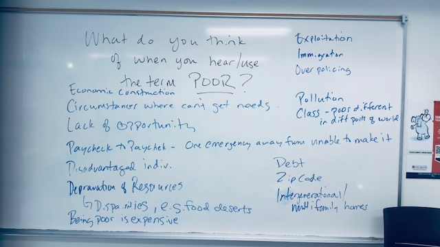

The first day’s question: what do you think of when you hear “poor”?

Your answers were causes and conditions, not people

**Thank you.**

*Your board, Week 1*